# CHD Classification

## 1. Introduction

The goal of this project is to apply various machine learning techniques to a medical dataset to achieve the most accurate prediction of CHD risk possible. I will compare different classification models and identify the most predictive factors.

The notebook runs through in one go in a few seconds, provided the installation (next cell) has been performed correctly.

The following packages need to be installed:

```
conda install scikit-learn conda-forge::umap-learn seaborn numpy=1.26.4
```

- **scikit-learn** as base package for ML
- **umap-learn** as extension of scikit for UMAP dimension reduction
- **seaborn** for better visualizations
- **numpy=1.26.4** as fix for incompatibility between umap-learn and scikit-learn (Breaking-Change in numpy 2.0)

## 2. Imports

```python
# Data management and analysis
import pandas as pd
import numpy as np
import matplotlib.pyplot as plt
import seaborn as sns

# Data scaling and preprocessing
from sklearn.preprocessing import StandardScaler, LabelEncoder
from sklearn.model_selection import train_test_split

# Dimension reduction
from sklearn.decomposition import PCA
from sklearn.manifold import TSNE
import umap

# Classification algorithms
from sklearn.neighbors import KNeighborsClassifier
from sklearn.svm import SVC
from sklearn.linear_model import LogisticRegression
from sklearn.tree import DecisionTreeClassifier
from sklearn.ensemble import RandomForestClassifier, GradientBoostingClassifier
from sklearn.neural_network import MLPClassifier

# Evaluation metrics
from sklearn.metrics import (
    confusion_matrix,
    roc_curve,
    auc,
    precision_recall_curve,
)

import warnings

warnings.filterwarnings("ignore")

# For reproducible results
np.random.seed(42)
```

## 3. Dataset

### 3.1 Load and examine data:

```python
# Load the dataset
data = pd.read_csv("CHD_Classification.csv")

# Check the first rows
print("First 5 rows of the dataset:")
data.head()
```

```
First 5 rows of the dataset:
```

|  | Age | Gender | BloodPressure | Chol | BloodSugar | ECG | HFmax | AP | RZ | CHD |
| --- | --- | --- | --- | --- | --- | --- | --- | --- | --- | --- |
| 0 | 40 | M | 140 | 289 | 0 | Normal | 172 | N | 0.0 | 0 |
| 1 | 49 | F | 160 | 180 | 0 | Normal | 156 | N | 1.0 | 1 |
| 2 | 37 | M | 130 | 283 | 0 | ST | 98 | N | 0.0 | 0 |
| 3 | 48 | F | 138 | 214 | 0 | Normal | 108 | Y | 1.5 | 1 |
| 4 | 54 | M | 150 | 195 | 0 | Normal | 122 | N | 0.0 | 0 |

### 3.2 Check dataset dimensions

```python
print("\nDataset dimensions (rows, columns):", data.shape)

# Check data types and missing values
print("\nData types and missing values:")
data.info()
```

```
Dataset dimensions (rows, columns): (918, 10)

Data types and missing values:
<class 'pandas.core.frame.DataFrame'>
RangeIndex: 918 entries, 0 to 917
Data columns (total 10 columns):
 #   Column         Non-Null Count  Dtype
---  ------         --------------  -----
 0   Age            918 non-null    int64
 1   Gender         918 non-null    object
 2   BloodPressure  918 non-null    int64
 3   Chol           918 non-null    int64
 4   BloodSugar     918 non-null    int64
 5   ECG            918 non-null    object
 6   HFmax          918 non-null    int64
 7   AP             918 non-null    object
 8   RZ             918 non-null    float64
 9   CHD            918 non-null    int64
dtypes: float64(1), int64(6), object(3)
memory usage: 71.8+ KB
```

### 3.3 Statistical summary of numerical variables

```python
print("\nStatistical summary of numerical variables:")
data.describe()
```

```
Statistical summary of numerical variables:
```

|  | Age | BloodPressure | Chol | BloodSugar | HFmax | RZ | CHD |
| --- | --- | --- | --- | --- | --- | --- | --- |
| count | 918.000000 | 918.000000 | 918.000000 | 918.000000 | 918.000000 | 918.000000 | 918.000000 |
| mean | 53.510893 | 132.396514 | 198.799564 | 0.233115 | 136.809368 | 0.887364 | 0.553377 |
| std | 9.432617 | 18.514154 | 109.384145 | 0.423046 | 25.460334 | 1.066570 | 0.497414 |
| min | 28.000000 | 0.000000 | 0.000000 | 0.000000 | 60.000000 | -2.600000 | 0.000000 |
| 25% | 47.000000 | 120.000000 | 173.250000 | 0.000000 | 120.000000 | 0.000000 | 0.000000 |
| 50% | 54.000000 | 130.000000 | 223.000000 | 0.000000 | 138.000000 | 0.600000 | 1.000000 |
| 75% | 60.000000 | 140.000000 | 267.000000 | 0.000000 | 156.000000 | 1.500000 | 1.000000 |
| max | 77.000000 | 200.000000 | 603.000000 | 1.000000 | 202.000000 | 6.200000 | 1.000000 |

### 3.4 Check class distribution (CHD)

```python
print("\nClass distribution (% CHD):")
print(data["CHD"].value_counts(normalize=True).round(3) * 100)
```

```
Class distribution (% CHD):
CHD
1    55.3
0    44.7
Name: proportion, dtype: float64
```

## 4. Machine Learning Model Evaluation

### 4.1 Data Preparation

I clean the data and prepare it for further analysis.

Cholesterol values of 0 are likely incomplete data. I need to treat these differently and replace them. I choose - if available - a suitable comparison group in my dataset. Otherwise the median.

```python
# Median of cholesterol values for normal values
median_chol = data[data["Chol"] > 0]["Chol"].median()

# Create binary indicator to possibly better track the distribution of cholesterol values later
data["Chol_was_zero"] = (data["Chol"] == 0).astype(int)


def impute_chol(row):
    if row["Chol"] > 0:
        return row["Chol"]

    # Select similar patients (same gender, similar age)
    similar = data[
        (data["Gender"] == row["Gender"])
        & (abs(data["Age"] - row["Age"]) < 5)
        & (data["Chol"] > 0)
    ]

    if len(similar) > 0:
        return similar["Chol"].median()
    else:
        return median_chol


# Apply imputation
data["Chol"] = data.apply(impute_chol, axis=1)
```

There exists one value with BloodPressure = 0. Since there's only one entry, I decide to remove it.

```python
data = data[data["BloodPressure"] != 0]
```

##### Encodings for categorical or non-numerical values

In this cell I encode the categorical variables "Gender", "AP" and "ECG". For "Gender" and "AP" I use `LabelEncoder`, since these variables each contain only two categories. By using `LabelEncoder` I save myself one additional column each, which would arise with One-Hot-Encoding. Probably negligible performance gain, but maximally efficient.

For the variable "ECG", which has more than two categories, I use One-Hot-Encoding to transform each category into a separate column. This enables a clear and unambiguous representation of the different categories of "ECG".

```python
# Encode categorical variables
le_gender = LabelEncoder()
le_ap = LabelEncoder()

data["Gender_encoded"] = le_gender.fit_transform(data["Gender"])
data["AP_encoded"] = le_ap.fit_transform(data["AP"])

# One-Hot-Encoding instead of LabelEncoder
ecg_dummies = pd.get_dummies(data["ECG"], prefix="ECG", dtype=int)
data = pd.concat([data, ecg_dummies], axis=1)

# Display mapping of encoded values
print("\nEncoding for Gender:")
for i, category in enumerate(le_gender.classes_):
    print(f"{category}: {i}")

print("\nEncoding for AP:")
for i, category in enumerate(le_ap.classes_):
    print(f"{category}: {i}")

print("\nEncoding for ECG:")
for i, col in enumerate(ecg_dummies.columns):
    print(f"{col}: 1 if ECG = '{col.split('_')[1]}', otherwise 0")
```

```
Encoding for Gender:
F: 0
M: 1

Encoding for AP:
N: 0
Y: 1

Encoding for ECG:
ECG_LVH: 1 if ECG = 'LVH', otherwise 0
ECG_Normal: 1 if ECG = 'Normal', otherwise 0
ECG_ST: 1 if ECG = 'ST', otherwise 0
```

### 4.2 Split data into training and test sets

```python
# Create a new DataFrame with numerical values for ML training
X_data = data[
    [
        "Age",
        "BloodPressure",
        "Chol",
        "BloodSugar",
        "HFmax",
        "RZ",
        "Gender_encoded",
        "ECG_LVH",
        "ECG_Normal",
        "ECG_ST",
        "AP_encoded",
    ]
]
y_data = data["CHD"]
```

Data is assigned 75% to the training set.

```python
X_train, X_test, y_train, y_test = train_test_split(
    X_data, y_data, test_size=0.25, random_state=42, stratify=y_data
)

print("\nDimensions of training and test sets:")
print(f"X_train: {X_train.shape}")
print(f"X_test: {X_test.shape}")
print(f"y_train: {y_train.shape}")
print(f"y_test: {y_test.shape}")
```

```
Dimensions of training and test sets:
X_train: (687, 11)
X_test: (230, 11)
y_train: (687,)
y_test: (230,)
```

##### Verification of the stratify option effect

```
stratify=y_data
```

ensures that the distribution of our target vector remains the same in the splits, i.e. approximately 55% CHD=1 and 45% CHD=0, as already seen in a previous cell and verified again here:

```python
# Original class distribution
print("Original class distribution (CHD):")
print(y_data.value_counts(normalize=True).round(4) * 100)

# Distribution in training and test set (with stratify)
print("\nTraining set:")
print(y_train.value_counts(normalize=True).round(4) * 100)
print("\nTest set:")
print(y_test.value_counts(normalize=True).round(4) * 100)
```

```
Original class distribution (CHD):
CHD
1    55.29
0    44.71
Name: proportion, dtype: float64

Training set:
CHD
1    55.31
0    44.69
Name: proportion, dtype: float64

Test set:
CHD
1    55.22
0    44.78
Name: proportion, dtype: float64
```

### 4.3 Exploratory Data Analysis

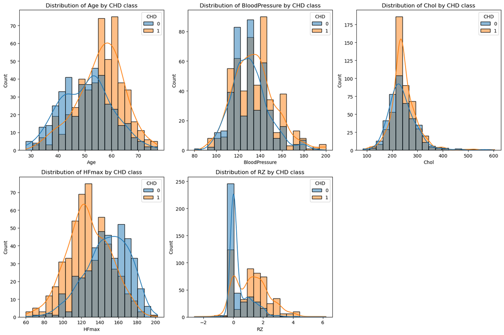

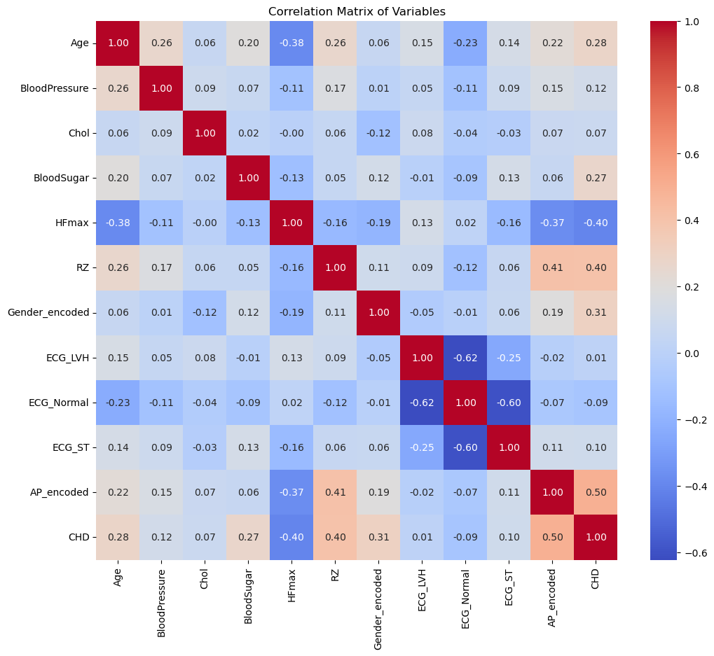

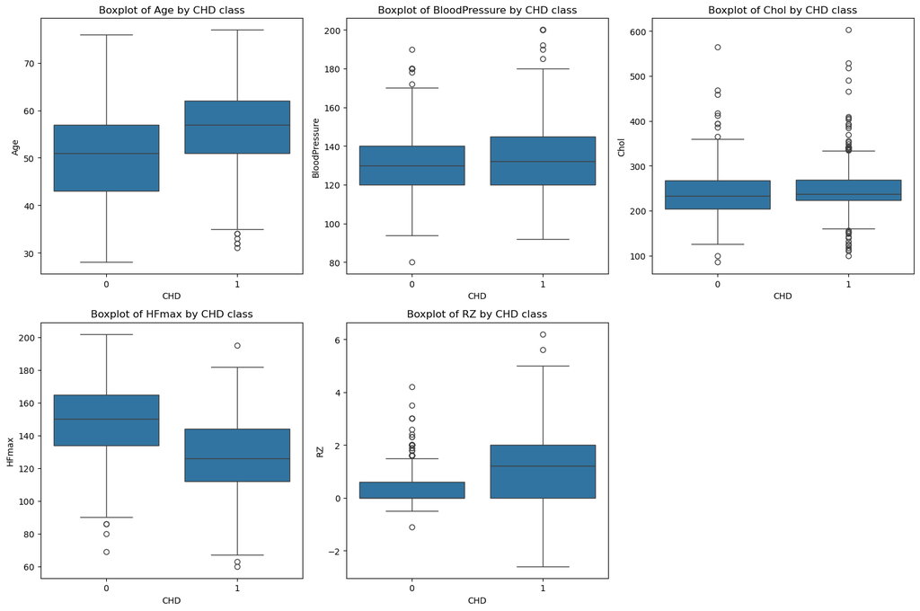

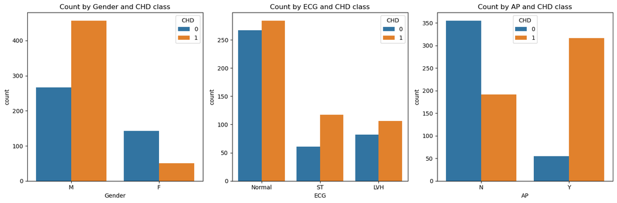

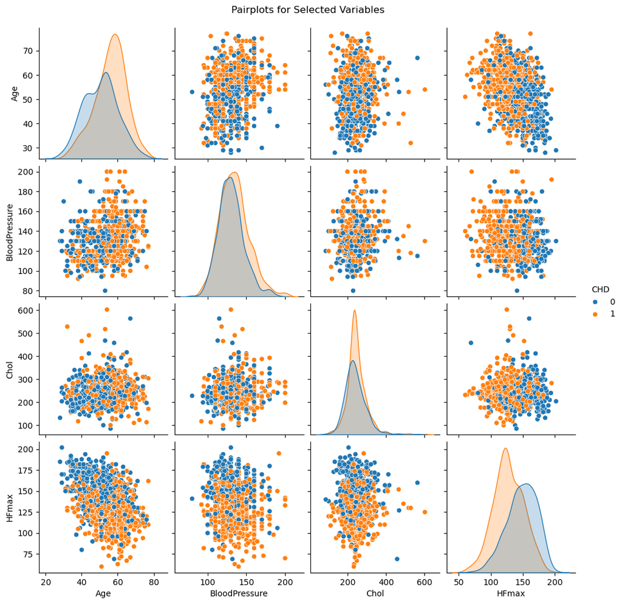

```python
# Visualize distribution of numerical variables
plt.figure(figsize=(15, 10))
for i, column in enumerate(["Age", "BloodPressure", "Chol", "HFmax", "RZ"]):
    plt.subplot(2, 3, i + 1)
    sns.histplot(data=data, x=column, hue="CHD", kde=True, bins=20)
    plt.title(f"Distribution of {column} by CHD class")
plt.tight_layout()
plt.show()

# Correlation matrix
plt.figure(figsize=(12, 10))
correlation_matrix = X_data.join(y_data).corr()
sns.heatmap(correlation_matrix, annot=True, cmap="coolwarm", fmt=".2f")
plt.title("Correlation Matrix of Variables")
plt.show()

# Boxplots for numerical variables by CHD class
plt.figure(figsize=(15, 10))
for i, column in enumerate(["Age", "BloodPressure", "Chol", "HFmax", "RZ"]):
    plt.subplot(2, 3, i + 1)
    sns.boxplot(x="CHD", y=column, data=data)
    plt.title(f"Boxplot of {column} by CHD class")
plt.tight_layout()
plt.show()

# Distribution of categorical variables
plt.figure(figsize=(15, 5))
for i, column in enumerate(["Gender", "ECG", "AP"]):
    plt.subplot(1, 3, i + 1)
    sns.countplot(x=column, hue="CHD", data=data)
    plt.title(f"Count by {column} and CHD class")
plt.tight_layout()
plt.show()

# Pairplots for some important variables
plt.figure(figsize=(12, 10))
sns.pairplot(data[["Age", "BloodPressure", "Chol", "HFmax", "CHD"]], hue="CHD")
plt.suptitle("Pairplots for Selected Variables", y=1.02)
plt.show()
```

### 4.4 Dimension Reduction and Visualization

#### 4.4.1 PCA (Principal Component Analysis)

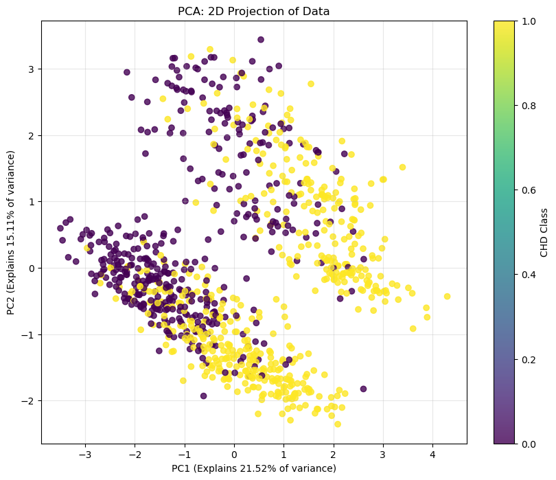

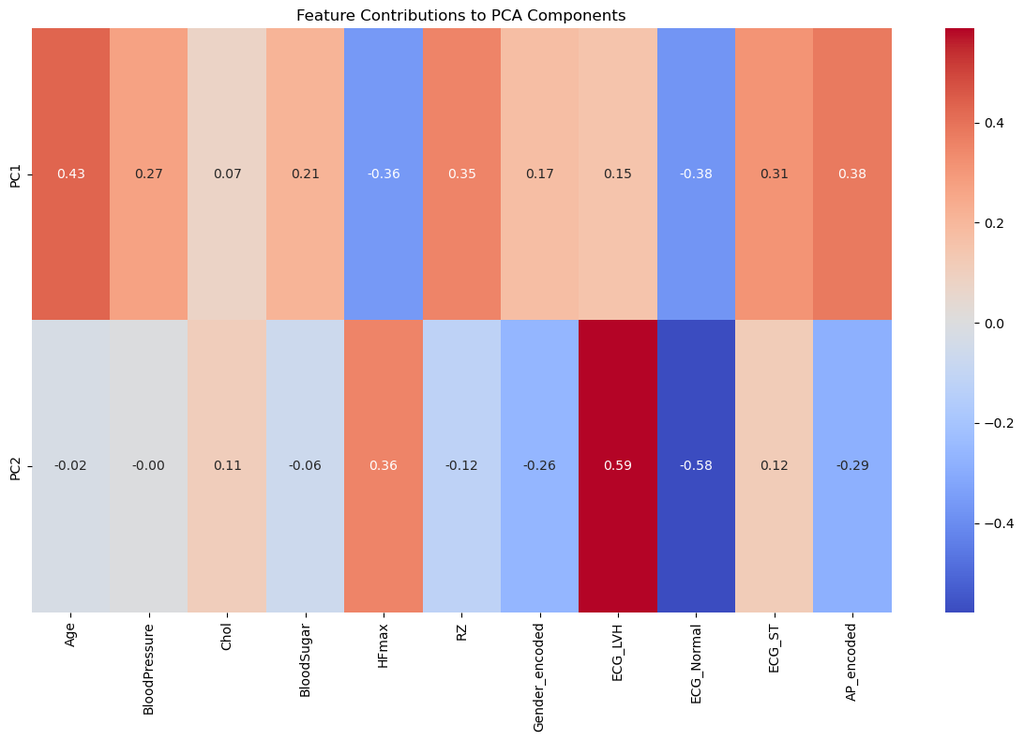

```python
# Standardize data for PCA
scaler = StandardScaler()
X_scaled = scaler.fit_transform(X_data)

# Apply PCA
pca = PCA(n_components=2)
X_pca = pca.fit_transform(X_scaled)

# Visualize PCA results
plt.figure(figsize=(10, 8))
scatter = plt.scatter(X_pca[:, 0], X_pca[:, 1], c=y_data, cmap="viridis", alpha=0.8)
plt.title("PCA: 2D Projection of Data")
plt.xlabel(f"PC1 (Explains {pca.explained_variance_ratio_[0]:.2%} of variance)")
plt.ylabel(f"PC2 (Explains {pca.explained_variance_ratio_[1]:.2%} of variance)")
plt.colorbar(scatter, label="CHD Class")
plt.grid(True, alpha=0.3)
plt.show()

# Feature contributions to the first two principal components
component_names = ["PC1", "PC2"]
feature_names = X_data.columns
pca_components = pd.DataFrame(
    pca.components_, columns=feature_names, index=component_names
)

plt.figure(figsize=(12, 8))
sns.heatmap(pca_components, annot=True, cmap="coolwarm", fmt=".2f")
plt.title("Feature Contributions to PCA Components")
plt.tight_layout()
plt.show()
```

#### 4.4.2 t-SNE (t-Distributed Stochastic Neighbor Embedding)

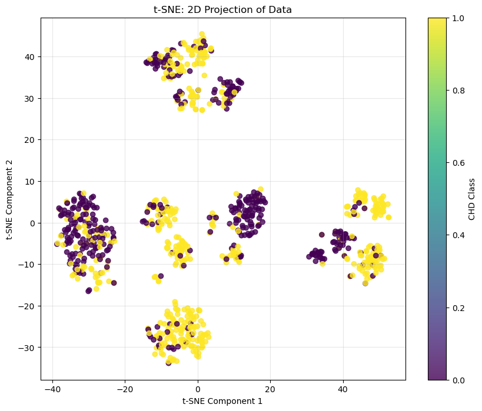

```python
# Apply t-SNE
tsne = TSNE(n_components=2, random_state=42, perplexity=30, n_iter=1000)
X_tsne = tsne.fit_transform(X_scaled)

# Visualize t-SNE results
plt.figure(figsize=(10, 8))
scatter = plt.scatter(X_tsne[:, 0], X_tsne[:, 1], c=y_data, cmap="viridis", alpha=0.8)
plt.title("t-SNE: 2D Projection of Data")
plt.xlabel("t-SNE Component 1")
plt.ylabel("t-SNE Component 2")
plt.colorbar(scatter, label="CHD Class")
plt.grid(True, alpha=0.3)
plt.show()
```

#### 4.4.3 UMAP

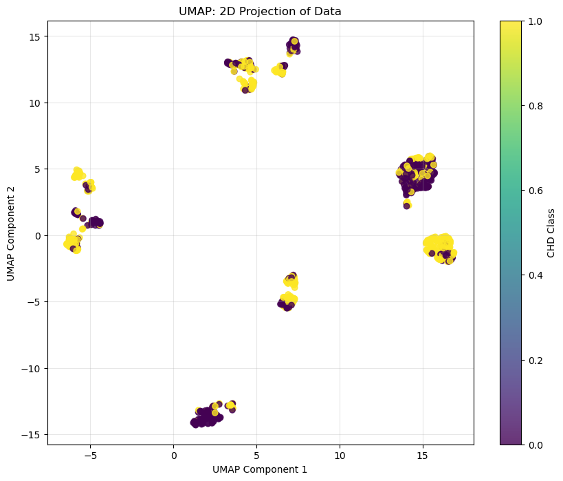

```python
# Apply UMAP
reducer = umap.UMAP(random_state=42)
X_umap = reducer.fit_transform(X_scaled)

# Visualize UMAP results
plt.figure(figsize=(10, 8))
scatter = plt.scatter(X_umap[:, 0], X_umap[:, 1], c=y_data, cmap="viridis", alpha=0.8)
plt.title("UMAP: 2D Projection of Data")
plt.xlabel("UMAP Component 1")
plt.ylabel("UMAP Component 2")
plt.colorbar(scatter, label="CHD Class")
plt.grid(True, alpha=0.3)
plt.show()
```

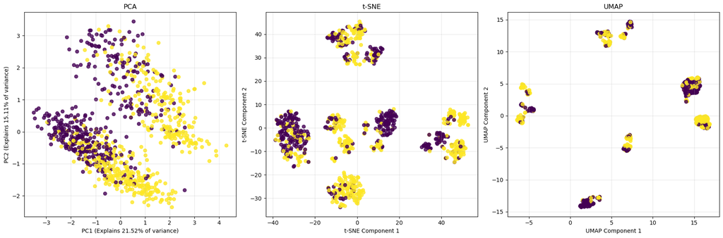

```
Evaluation of dimension reduction methods:
PCA: The first two principal components explain 36.63% of total variance.
The visualizations show that the classes are not perfectly separable, but certain clusters are recognizable.
```

```python
# Comparison of the three dimension reduction methods
plt.figure(figsize=(18, 6))

plt.subplot(1, 3, 1)
plt.scatter(X_pca[:, 0], X_pca[:, 1], c=y_data, cmap="viridis", alpha=0.8)
plt.title("PCA")
plt.xlabel(f"PC1 (Explains {pca.explained_variance_ratio_[0]:.2%} of variance)")
plt.ylabel(f"PC2 (Explains {pca.explained_variance_ratio_[1]:.2%} of variance)")
plt.grid(True, alpha=0.3)

plt.subplot(1, 3, 2)
plt.scatter(X_tsne[:, 0], X_tsne[:, 1], c=y_data, cmap="viridis", alpha=0.8)
plt.title("t-SNE")
plt.xlabel("t-SNE Component 1")
plt.ylabel("t-SNE Component 2")
plt.grid(True, alpha=0.3)

plt.subplot(1, 3, 3)
plt.scatter(X_umap[:, 0], X_umap[:, 1], c=y_data, cmap="viridis", alpha=0.8)
plt.title("UMAP")
plt.xlabel("UMAP Component 1")
plt.ylabel("UMAP Component 2")
plt.grid(True, alpha=0.3)

plt.tight_layout()
plt.show()

# Evaluation of dimension reductions and visualizations
print("Evaluation of dimension reduction methods:")
print(
    "PCA: The first two principal components explain {:.2%} of total variance.".format(
        pca.explained_variance_ratio_[0] + pca.explained_variance_ratio_[1]
    )
)
print(
    "The visualizations show that the classes are not perfectly separable, but certain clusters are recognizable."
)
```

### 4.5 Training and Evaluation of Various Classification Models

I implement and compare various classification algorithms with empirically chosen hyperparameters.

```python
from helpers.eval_model import evaluate_model

# Scale training data
scaler = StandardScaler()
X_train_scaled = scaler.fit_transform(X_train)
X_test_scaled = scaler.transform(X_test)

# Define various models
models = {
    "K-Nearest Neighbors": KNeighborsClassifier(n_neighbors=5),
    "Support Vector Machine": SVC(kernel="rbf", probability=True),
    "Logistic Regression": LogisticRegression(max_iter=1000),
    "Decision Tree": DecisionTreeClassifier(),
    "Random Forest": RandomForestClassifier(),
    "Gradient Boosting": GradientBoostingClassifier(),
    "Neural Network": MLPClassifier(hidden_layer_sizes=(100, 50), max_iter=1000),
}
```

```python
# Evaluate models
results = {}
for name, model in models.items():
    results[name] = evaluate_model(
        model, X_train_scaled, X_test_scaled, y_train, y_test, X_data, y_data
    )
    print(
        f"{name} - Accuracy: {results[name]['accuracy']:.4f}, F1: {results[name]['f1']:.4f}, CV: {results[name]['cv_mean']:.4f} ± {results[name]['cv_std']:.4f}"
    )

# Display results in a table
results_df = pd.DataFrame(
    {
        "Model": list(results.keys()),
        "Accuracy": [results[model]["accuracy"] for model in results],
        "Precision": [results[model]["precision"] for model in results],
        "Recall": [results[model]["recall"] for model in results],
        "F1-Score": [results[model]["f1"] for model in results],
        "CV (Mean)": [results[model]["cv_mean"] for model in results],
        "CV (Std)": [results[model]["cv_std"] for model in results],
    }
)

print("\nSummary of Model Results: (Sorted by F1-Score)")
results_df.sort_values("F1-Score", ascending=False)
```

[output not shown]

|  | Model | Accuracy | Precision | Recall | F1-Score | CV (Mean) | CV (Std) |
| --- | --- | --- | --- | --- | --- | --- | --- |
| 1 | Support Vector Machine | 0.839130 | 0.835821 | 0.881890 | 0.858238 | 0.679437 | 0.054596 |
| 0 | K-Nearest Neighbors | 0.830435 | 0.849206 | 0.842520 | 0.845850 | 0.652079 | 0.034309 |
| 2 | Logistic Regression | 0.826087 | 0.848000 | 0.834646 | 0.841270 | 0.773135 | 0.019526 |
| 4 | Random Forest | 0.817391 | 0.829457 | 0.842520 | 0.835938 | 0.750261 | 0.019798 |
| 5 | Gradient Boosting | 0.813043 | 0.838710 | 0.818898 | 0.828685 | 0.751414 | 0.042056 |
| 6 | Neural Network | 0.765217 | 0.787402 | 0.787402 | 0.787402 | 0.752435 | 0.024417 |
| 3 | Decision Tree | 0.760870 | 0.785714 | 0.779528 | 0.782609 | 0.657567 | 0.037799 |

[figure not shown]

```python
fig, axes = plt.subplots(1, 2, figsize=(20, 8))

# First subplot: Metrics
results_df.sort_values("F1-Score").plot(
    x="Model",
    y=["Accuracy", "Precision", "Recall", "F1-Score"],
    kind="bar",
    ax=axes[0],
)
axes[0].set_title("Comparison of Model Performance")
axes[0].set_ylabel("Score")
axes[0].set_ylim(0, 1.0)  # Uniform y-axis
axes[0].grid(axis="y", alpha=0.3)

# Second subplot: Cross-validation
sns.barplot(
    x="Model", y="CV (Mean)", data=results_df.sort_values("F1-Score"), ax=axes[1]
)
axes[1].errorbar(
    x=range(len(results_df)),
    y=results_df.sort_values("F1-Score")["CV (Mean)"],
    yerr=results_df.sort_values("F1-Score")["CV (Std)"],
    fmt="none",
    c="black",
    capsize=5,
)
axes[1].set_title("Cross-Validation Results")
axes[1].set_ylabel("Mean CV Accuracy")
axes[1].set_ylim(0, 1.0)  # Uniform y-axis
axes[1].grid(axis="y", alpha=0.3)

for ax in axes:
    plt.sca(ax)
    plt.xticks(rotation=45, ha="right")

plt.tight_layout(pad=3.0)
plt.show()
```

#### 4.5.1 Model Results

The observed discrepancy between test and cross-validation scores for some models indicates a certain degree of overfitting. Based on these results, I will **select SVM, KNN and Logistic Regression (the 3 best models) for further analysis and optimization**.

#### 4.5.2 Detailed Analysis of Best Models

```python
best_models = {
    "Support Vector Machine": models["Support Vector Machine"],
    "K-Nearest Neighbors": models["K-Nearest Neighbors"],
    "Logistic Regression": models["Logistic Regression"],
}
```

Based on my first evaluation, I found that SVM, K-Nearest Neighbors and Logistic Regression are among the most powerful models. Now I want to analyze these three models in more detail to get a better understanding of their strengths and weaknesses.

I will investigate the following aspects:

1. Confusion matrices of the models
2. ROC curves and AUC values
3. Distribution of prediction probabilities

These analyses will help me understand how the models make decisions and where they have difficulties.

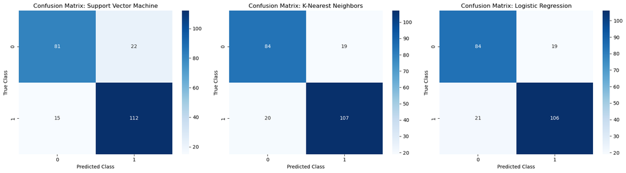

```python
# Confusion matrices for the best models
fig, axes = plt.subplots(1, 3, figsize=(18, 5))

for i, (name, model) in enumerate(best_models.items()):
    y_pred = model.predict(X_test_scaled)

    cm = confusion_matrix(y_test, y_pred)
    sns.heatmap(cm, annot=True, fmt="d", cmap="Blues", ax=axes[i])
    axes[i].set_title(f"Confusion Matrix: {name}")
    axes[i].set_xlabel("Predicted Class")
    axes[i].set_ylabel("True Class")

plt.tight_layout()
plt.show()
```

##### Confusion Matrices:

- **Support Vector Machine**: Shows strong recognition performance for CHD-positive cases (112 TP), but has more False Positives (22 FP) than the other models. The SVM seems to tend to classify patients as CHD-positive, leading to high sensitivity (88.2%) at the cost of specificity (78.6%).
- **K-Nearest Neighbors**: Offers more balanced performance with better recognition of negative cases (84 TN) compared to SVM, but shows more False Negatives (20 FN). KNN has lower sensitivity (84.3%), but higher specificity (81.6%).
- **Logistic Regression**: Behaves similarly to KNN with identical specificity (81.6%), but has slightly more False Negatives (21 FN), resulting in slightly lower sensitivity (83.5%).

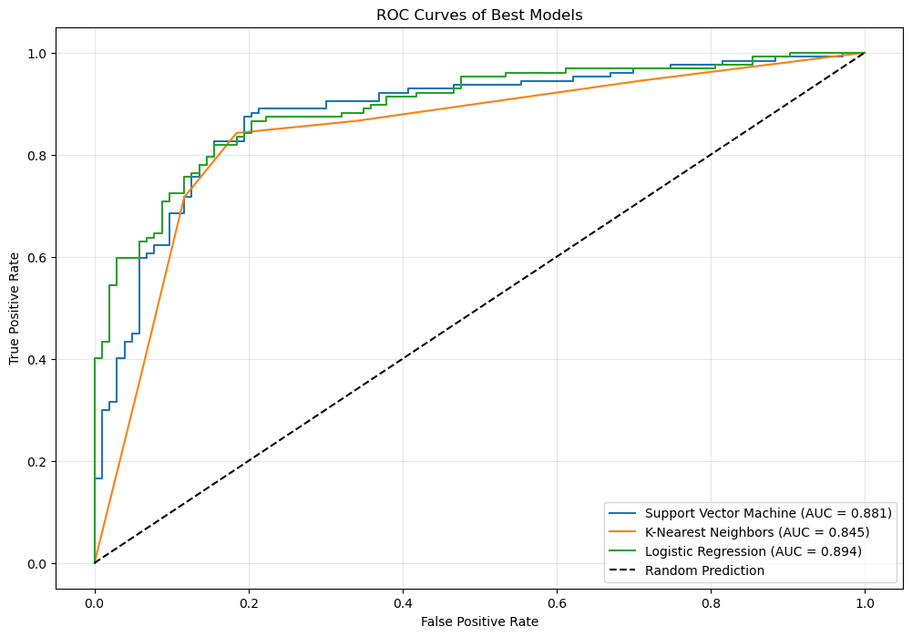

```python
# ROC curves for the best models
plt.figure(figsize=(12, 8))

for name, model in best_models.items():
    # model.fit(X_train_scaled, y_train)
    y_pred_proba = model.predict_proba(X_test_scaled)[:, 1]

    fpr, tpr, _ = roc_curve(y_test, y_pred_proba)
    roc_auc = auc(fpr, tpr)

    plt.plot(fpr, tpr, label=f"{name} (AUC = {roc_auc:.3f})")

plt.plot([0, 1], [0, 1], "k--", label="Random Prediction")
plt.xlabel("False Positive Rate")
plt.ylabel("True Positive Rate")
plt.title("ROC Curves of Best Models")
plt.legend()
plt.grid(True, alpha=0.3)
plt.show()
```

##### ROC Curves:

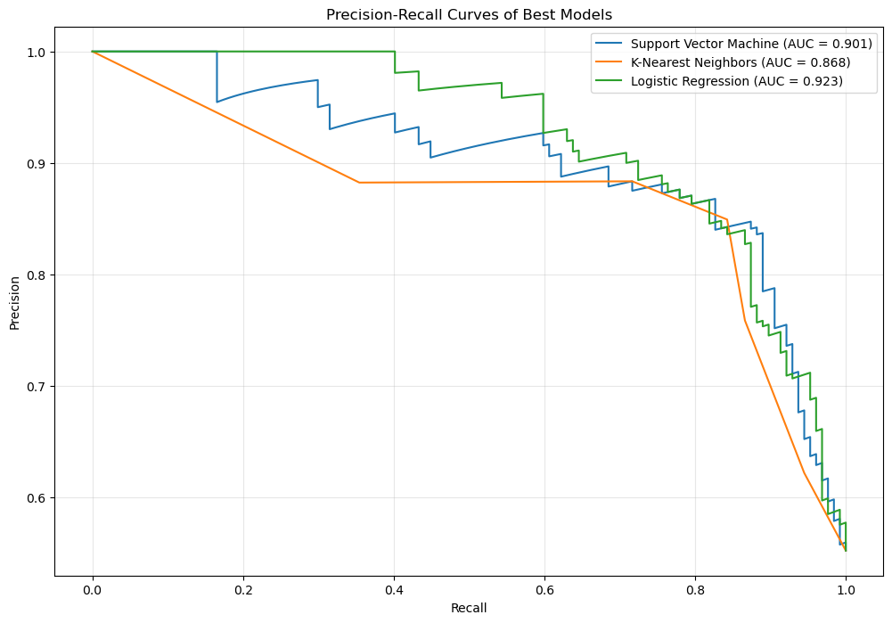

```python
plt.figure(figsize=(12, 8))

for name, model in best_models.items():
    # model.fit(X_train_scaled, y_train)
    y_pred_proba = model.predict_proba(X_test_scaled)[:, 1]

    precision, recall, _ = precision_recall_curve(y_test, y_pred_proba)
    pr_auc = auc(recall, precision)

    plt.plot(recall, precision, label=f"{name} (AUC = {pr_auc:.3f})")

plt.xlabel("Recall")
plt.ylabel("Precision")
plt.title("Precision-Recall Curves of Best Models")
plt.legend()
plt.grid(True, alpha=0.3)
plt.show()
```

##### Precision-Recall Curves:

When considering Precision and Recall, especially important for unbalanced data:

- **Logistic Regression** dominates with the highest AUC (0.923) and shows excellent precision values particularly in the middle recall range (0.4-0.7)
- **SVM** (AUC = 0.901) shows stronger fluctuations in precision, but maintains good values even at higher recall
- **KNN** (AUC = 0.868) drops more quickly especially in the high recall range

##### Conclusion:

Logistic regression offers the best balance across all metrics, particularly for a medical context where both false positive and false negative results can be critical. SVM could be preferred if higher sensitivity is more important (e.g., for screening purposes), while KNN shows the most stable performance in correctly identifying non-CHD cases.

#### 4.5.3 Hyperparameter Optimization of Best Models

After examining the models more closely, I can now determine the optimal hyperparameters for each of the top models using Grid Search.

```python
# Hyperparameter grids for the best models
param_grids = {
    "Support Vector Machine": {
        "C": [0.1, 1, 10, 100],
        "gamma": ["scale", "auto", 0.01, 0.1, 1],
        "kernel": ["rbf", "linear", "poly"],
    },
    "Logistic Regression": {
        "C": [0.01, 0.1, 1, 10, 100],
        "penalty": ["l1", "l2", "elasticnet"],
        "solver": ["liblinear", "saga", "lbfgs"],
        "max_iter": [1000],
    },
    "K-Nearest Neighbors": {
        "n_neighbors": [3, 5, 7, 9, 11],
        "weights": ["uniform", "distance"],
        "metric": ["euclidean", "manhattan", "minkowski"],
    },
}
```

```python
from helpers.optimizer import optimize_hyperparameters


# Perform Grid Search for the best models
optimized_models = {}

for name, model in best_models.items():
    optimized_models[name] = optimize_hyperparameters(
        name, model, param_grids[name], X_train_scaled, y_train
    )

# Evaluation of optimized models
print("\nEvaluation of optimized models:")
optimized_results = {}

for name, model in optimized_models.items():
    optimized_results[name] = evaluate_model(
        model, X_train_scaled, X_test_scaled, y_train, y_test, X_data, y_data
    )

# Display results in a table
optimized_df = pd.DataFrame(
    {
        "Model": list(optimized_results.keys()),
        "Accuracy": [
            optimized_results[model]["accuracy"] for model in optimized_results
        ],
        "Precision": [
            optimized_results[model]["precision"] for model in optimized_results
        ],
        "Recall": [optimized_results[model]["recall"] for model in optimized_results],
        "F1-Score": [optimized_results[model]["f1"] for model in optimized_results],
        "CV (Mean)": [
            optimized_results[model]["cv_mean"] for model in optimized_results
        ],
        "CV (Std)": [optimized_results[model]["cv_std"] for model in optimized_results],
    }
)

print("\nSummary of optimized model results: (Sorted by F1-Score)")
print(optimized_df.sort_values("F1-Score", ascending=False))

# Comparison of results before and after optimization
comparison_df = pd.DataFrame(
    {
        "Model": list(results.keys())[:3],  # Only the three best models
        "F1 (before optimization)": [
            results[model]["f1"] for model in list(results.keys())[:3]
        ],
        "F1 (after optimization)": [
            optimized_results[model]["f1"] for model in optimized_results
        ],
        "Improvement": [
            optimized_results[model]["f1"] - results[list(results.keys())[i]]["f1"]
            for i, model in enumerate(optimized_results)
        ],
    }
)

print("\nComparison of F1-Scores before and after hyperparameter optimization:")
comparison_df
```

[output not shown]

|  | Model | F1 (before optimization) | F1 (after optimization) | Improvement |
| --- | --- | --- | --- | --- |
| 0 | K-Nearest Neighbors | 0.845850 | 0.858238 | 0.012388 |
| 1 | Support Vector Machine | 0.858238 | 0.851406 | -0.006832 |
| 2 | Logistic Regression | 0.841270 | 0.836653 | -0.004616 |

#### 4.5.4 Visualization of Decision Boundaries

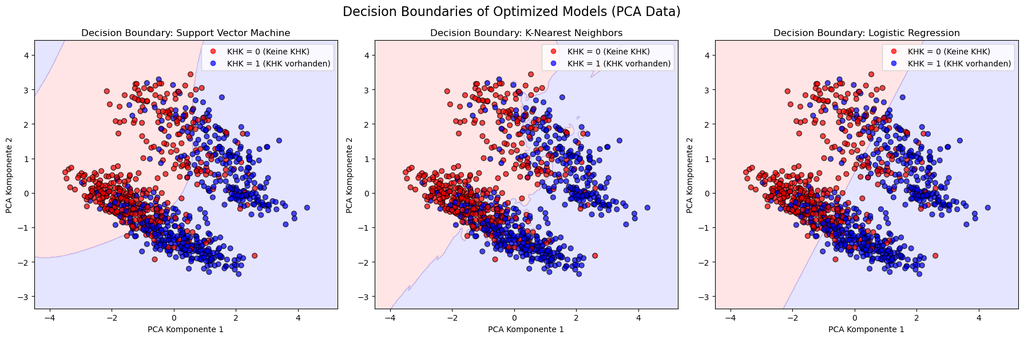

```python
# PCA for visualization of decision boundaries
from sklearn import clone
from helpers.plotters import plot_decision_boundary


pca_vis = PCA(n_components=2)
X_pca_vis = pca_vis.fit_transform(X_scaled)

# Train the optimized models on PCA data
X_train_pca, X_test_pca, y_train_pca, y_test_pca = train_test_split(
    X_pca_vis, y_data, test_size=0.25, random_state=42, stratify=y_data
)

# Visualize decision boundaries for the optimized models
fig, axes = plt.subplots(1, 3, figsize=(18, 6))

for i, (name, model) in enumerate(optimized_models.items()):
    # Train the model on PCA data
    model_pca = clone(model)
    model_pca.fit(X_train_pca, y_train_pca)

    # Plot decision boundary
    plot_decision_boundary(
        model_pca, X_pca_vis, y_data, title=f"Decision Boundary: {name}", ax=axes[i]
    )

plt.suptitle("Decision Boundaries of Optimized Models (PCA Data)", fontsize=16)
plt.tight_layout()
plt.show()
```

Here you can see the decision boundaries of the individual models. The basis for this is the PCA data, which were the visually best classifiable data in the previous visualizations.

### 4.6 Feature Importance and Feature Engineering

I analyze the importance of individual features for classification and try to improve model performance through feature engineering.

#### 4.6.1 Feature Importance

In logistic regression, I can measure the influence of individual features using the coefficients.

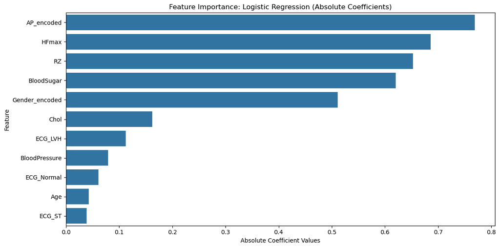

```python
# Feature Importance from Logistic Regression directly via coefficients
log_reg_model = optimized_models.get("Logistic Regression")

if log_reg_model:
    feature_importance_logreg = pd.DataFrame(
        {"Feature": X_data.columns, "Importance": np.abs(log_reg_model.coef_[0])}
    )
    feature_importance_logreg = feature_importance_logreg.sort_values(
        "Importance", ascending=False
    )

    plt.figure(figsize=(12, 6))
    sns.barplot(x="Importance", y="Feature", data=feature_importance_logreg)
    plt.title("Feature Importance: Logistic Regression (Absolute Coefficients)")
    plt.xlabel("Absolute Coefficient Values")
    plt.tight_layout()
    plt.show()
```

```python
print("Top 5 most important features (Logistic Regression with absolute coefficients):")
feature_importance_logreg.head(5)
```

```
Top 5 most important features (Logistic Regression with absolute coefficients):
```

|  | Feature | Importance |
| --- | --- | --- |
| 10 | AP_encoded | 0.768775 |
| 4 | HFmax | 0.685988 |
| 5 | RZ | 0.653049 |
| 3 | BloodSugar | 0.620675 |
| 6 | Gender_encoded | 0.511377 |

Here it's clearly visible that **AP** has the greatest influence, closely followed by **maximum heart rate** and **RZ**.

I therefore also look at the other two selected models, where I measure the feature importance using scikit-learn's `permutation_importance` function, aggregate and then display it.

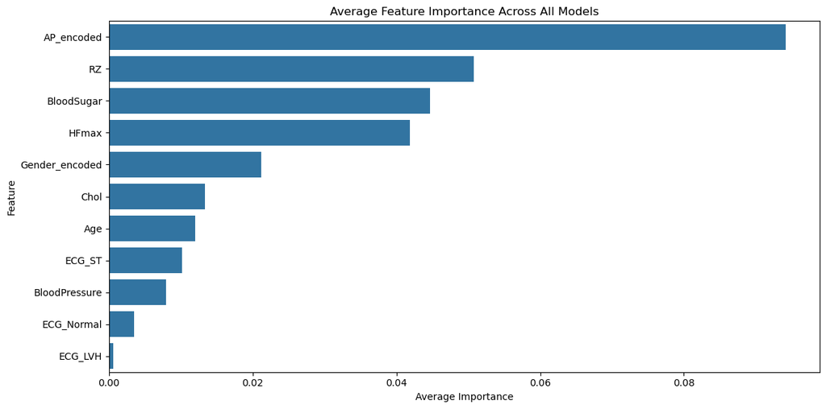

```python
# Here I could perform an aggregation of top features from all models
from sklearn.inspection import permutation_importance


all_importances = []

for name, model in optimized_models.items():
    model_clone = clone(model)
    model_clone.fit(X_train_scaled, y_train)

    # Calculate Permutation Importance
    result = permutation_importance(
        model_clone, X_test_scaled, y_test, n_repeats=10, random_state=42, n_jobs=-1
    )

    # Add results to list
    importance_df = pd.DataFrame(
        {
            "Feature": X_data.columns,
            "Importance": result.importances_mean,
            "Model": name,
        }
    )
    all_importances.append(importance_df)

# Combine all importance values
combined_importance = pd.concat(all_importances)

# Calculate average rank of each feature across all models
avg_rank = combined_importance.groupby("Feature")["Importance"].mean().reset_index()
avg_rank = avg_rank.sort_values("Importance", ascending=False)

# Visualize average importance
plt.figure(figsize=(12, 6))
sns.barplot(x="Importance", y="Feature", data=avg_rank)
plt.title("Average Feature Importance Across All Models")
plt.xlabel("Average Importance")
plt.tight_layout()
plt.show()
```

The Feature Importance analysis shows that **AP (Angina Pectoris) is the strongest predictor for CHD**, followed by RZ, BloodSugar and maximum heart rate.

These insights have direct clinical relevance as they align with known risk factors and symptoms. The high importance of AP confirms that this symptom is a strong indicator for the presence of CHD. It's also notable that especially the `ECG class "ST"` seems to be the most relevant ECG class.

The results suggest that an effective screening tool for CHD should prioritize these main features, with classical risk factors like cholesterol and blood pressure appearing less discriminative than the symptomatic indicators.

#### 4.6.2 Feature Engineering

Based on the Feature Importance analysis, I can now perform targeted feature engineering to further improve model performance.

##### The most important features based on my previous analysis

```python
top_features = list(avg_rank["Feature"].head(5))
print(f"Top 5 selected features for Feature Engineering: {top_features}")
```

```
Top 5 selected features for Feature Engineering: ['AP_encoded', 'RZ', 'BloodSugar', 'HFmax', 'Gender_encoded']
```

##### Various Feature Engineering Strategies

```python
from sklearn.preprocessing import PolynomialFeatures
from sklearn.feature_selection import SelectKBest, f_classif

engineering_strategies = {
    "Top Features Only": {
        "description": "Use only the top-5 most important features",
        "transform": lambda X: X[top_features],
    },
    "Polynomial Features": {
        "description": "Generate polynomial features (degree 2) from top features",
        "transform": lambda X: pd.DataFrame(
            PolynomialFeatures(degree=2, include_bias=False).fit_transform(
                X[top_features]
            ),
            # Generic column names that safely match the feature count
            columns=[
                f"poly_{i}"
                for i in range(
                    PolynomialFeatures(degree=2, include_bias=False)
                    .fit_transform(X[top_features][:1])
                    .shape[1]
                )
            ],
        ),
    },
    "Interaction Terms": {
        "description": "Add interaction terms between important numerical features",
        "transform": lambda X: pd.concat(
            [
                X,  # Keep original features
                pd.DataFrame(
                    {
                        "Age_BloodPressure": X["Age"] * X["BloodPressure"] / 100,
                        "Age_Chol": X["Age"] * X["Chol"] / 100,
                        "BloodPressure_HFmax": X["BloodPressure"] * X["HFmax"] / 100,
                        "Age_HFmax": X["Age"] * X["HFmax"] / 100,
                        "Chol_BloodSugar": X["Chol"] * X["BloodSugar"] / 100,
                    }
                ),
            ],
            axis=1,
        ),
    },
    "PCA Transformation": {
        "description": "Use the first 5 PCA components",
        "transform": lambda X: pd.DataFrame(
            PCA(n_components=5).fit_transform(StandardScaler().fit_transform(X)),
            columns=[f"PC{i+1}" for i in range(5)],
        ),
    },
    "Feature Selection (SelectKBest)": {
        "description": "Select the best k (=5) features using univariate statistics",
        "transform": lambda X: pd.DataFrame(
            SelectKBest(f_classif, k=5).fit_transform(X, y_data),
            columns=[
                X.columns[i]
                for i in SelectKBest(f_classif, k=5)
                .fit(X, y_data)
                .get_support(indices=True)
            ],
        ),
    },
}
```

##### Perform Feature Engineering Strategies for All Models

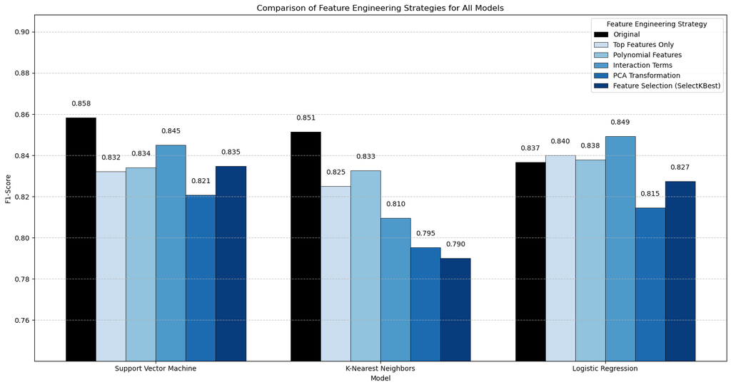

```python
# Convert results to DataFrame for easier plotting
from helpers.feature_engineering import test_feature_engineering_strategies


results_df = []
for model_name, strategies in test_feature_engineering_strategies(
    strategies=engineering_strategies,
    models=optimized_models,
    X_data=X_data,
    y_data=y_data,
).items():
    for strategy_name, f1_score in strategies.items():
        if f1_score is not None:  # Only valid results
            results_df.append(
                {"Model": model_name, "Strategy": strategy_name, "F1-Score": f1_score}
            )
results_df = pd.DataFrame(results_df)

# Create grouped bar chart
plt.figure(figsize=(15, 8))

# Define color palette - "Original" in different color
unique_strategies = results_df["Strategy"].unique()
colors = plt.cm.Blues(np.linspace(0.05, 0.95, len(unique_strategies)))
strategy_colors = {}
for i, strategy in enumerate(unique_strategies):
    if strategy == "Original":
        strategy_colors[strategy] = "black"  # Highlight original strategy
    else:
        strategy_colors[strategy] = colors[i]

# Number of models and bar width
unique_models = results_df["Model"].unique()
n_models = len(unique_models)
width = 0.8 / len(unique_strategies)  # Width of each bar

# X-positions for models
x = np.arange(n_models)

# Plot one bar per model for each strategy
for i, strategy in enumerate(unique_strategies):
    strategy_data = results_df[results_df["Strategy"] == strategy]

    # Ensure data is in correct order
    scores = []
    for model in unique_models:
        model_data = strategy_data[strategy_data["Model"] == model]
        scores.append(model_data["F1-Score"].values[0])

    offset = (i - len(unique_strategies) / 2 + 0.5) * width

    plt.bar(
        x + offset,
        scores,
        width,
        label=strategy,
        color=strategy_colors[strategy],
        edgecolor="black",
        linewidth=0.5,
    )

# Axis labels and layout
plt.xlabel("Model")
plt.ylabel("F1-Score")
plt.title("Comparison of Feature Engineering Strategies for All Models")
plt.xticks(x, unique_models)
plt.legend(title="Feature Engineering Strategy")
plt.grid(axis="y", linestyle="--", alpha=0.7)

# Adjust y-axis to better see small differences
min_score = max(0.6, results_df["F1-Score"].min() - 0.05)
max_score = min(1.0, results_df["F1-Score"].max() + 0.05)
plt.ylim(min_score, max_score)

# Display values above bars
for i, strategy in enumerate(unique_strategies):
    strategy_data = results_df[results_df["Strategy"] == strategy]

    for j, model in enumerate(unique_models):
        model_data = strategy_data[strategy_data["Model"] == model]
        if not model_data.empty:
            score = model_data["F1-Score"].values[0]
            offset = (i - len(unique_strategies) / 2 + 0.5) * width
            plt.text(
                j + offset,
                score + 0.005,
                f"{score:.3f}",
                ha="center",
                va="bottom",
                fontsize=10,
            )

plt.tight_layout()
plt.show()
```

##### Interpretation of Feature Engineering Results

The analysis of the Feature Engineering comparison shows different effects on the three models:

- For the **Support Vector Machine** (F1: 0.858), all applied strategies led to deterioration, with interaction terms (F1: 0.845) still performing best.
- For the **K-Nearest Neighbors** model (F1: 0.851), the performance drop from feature engineering was even more pronounced, with polynomial features (F1: 0.833) as the best alternative.
- Particularly interesting is the **Logistic Regression**, where interaction terms (F1: 0.849) actually achieved improvement over the original (F1: 0.837). This indicates that logistic regression benefits from explicit feature interactions, while more complex models like SVM can already implicitly capture relationships between features.

## 5. Summary, Conclusions and Outlook

I have implemented and compared various classification models for predicting CHD based on medical parameters. In doing so, I have both optimized the hyperparameters of the models and performed feature engineering.

My analyses have shown that the **Support Vector Machine (C=1, gamma=0.1, probability=True) delivers the best results**. The most important features for predicting CHD were AP (Angina Pectoris), maximum heart rate, RZ and whether the patient already has a blood sugar disease. These insights could be important in medical practice to identify patients with increased CHD risk early.

```python
optimized_df.head(3)
```

|  | Model | Accuracy | Precision | Recall | F1-Score | CV (Mean) | CV (Std) |
| --- | --- | --- | --- | --- | --- | --- | --- |
| 0 | Support Vector Machine | 0.839130 | 0.835821 | 0.881890 | 0.858238 | 0.557240 | 0.007019 |
| 1 | K-Nearest Neighbors | 0.839130 | 0.868852 | 0.834646 | 0.851406 | 0.675006 | 0.030381 |
| 2 | Logistic Regression | 0.821739 | 0.846774 | 0.826772 | 0.836653 | 0.773135 | 0.019526 |

In future work, the following aspects could be considered:

1. Inclusion of additional clinical parameters
2. Application of more complex neural networks (computationally intensive) or ensemble methods
3. Consideration of data imbalances through special sampling techniques
4. Analysis of interactions between different risk factors
5. External validation on independent datasets